# Midterm One

```r
library(knitr)
```

In this midterm we will analyze some data on the conservation status of species in North America and spending under the Endangered Species Act.

Answer the following questions by using chunks of R code. Comment on what your code does. Make sure to add informative axis titles and, where appropriate, units to your answers. Upload the R markdown file and knitted output to Canvas.

We will use the file `conservationdata.csv`. This data set has information on North American species. It has five variables that are described in the table below.

Table 1. Variables in “consevationdata.csv”

| Name | Description |
| --- | --- |
| speciesid | unique ID |
| speciesname | scientific name |
| taxon | Species group |
| conservation status | Conservation status in North America, according to [NatureServe](https://www.natureserve.org/conservation-tools/conservation-rank-calculator): 1 = Critically Imperiled; 2 = Imperiled; 3 = Vulnerable; … |
| listed | Is the species listed as threatened or endangered under the US Endangered Species Act: 0 = No; 1 = Yes |

Read the file `conservationdata.csv`

```r
setwd("C:\\Users\\Benny Panjaitan\\Documents\\GitHub\\esp106-Naomi\\Midterm")
consdata <- read.csv("conservationdata.csv")
```

1. What fraction of species in the data set are listed under the Endangered Species Act? (2 points)

```r
all <- nrow(consdata)
end <- nrow(consdata[consdata$listed == '1',])

all/end
```

```
## [1] 33.18367
```

```r
end/all*100
```

```
## [1] 3.01353
```

The fraction of species listed under the Endangered Species Act is **1/33.18367**, which means there is *1 endangered species for every 33.18367 species*. Or, there are **3.01353%** species are listed under the Endangered Species Act.

2. Show how many (absolute and relative) species there are for each taxonomic group by making a data.frame in which the first column has the taxonomic groups, the second column is the number of species in that group, and the third column is the percentage of all species in that group.

```r
tx <- as.data.frame(table(consdata$taxon))
tx <- cbind(tx, tx$Freq/all*100)
colnames(tx) <- c("Taxonomic Groups", "Number of Species", "Percentage (%)")
tx
```

```
##   Taxonomic Groups Number of Species Percentage (%)
## 1       Amphibians               319      0.5945059
## 2            Birds               795      1.4816057
## 3           Fishes              1453      2.7078907
## 4            Fungi              6270     11.6851169
## 5    Invertebrates             24407     45.4862276
## 6          Mammals               474      0.8833725
## 7           Plants             19511     36.3617727
## 8         Protists                79      0.1472287
## 9         Reptiles               350      0.6522793
```

3a) One interesting question is how the conservation status varies between different taxonomic groups. Make a plot showing the relative distribution of conservation status within each taxonomic group. There should be descriptive legend (with words, not with the numeric codes) (3 points)

You can use a “base” plotting method, or ggplot. If you are using ggplot, stat=“count” (counts up and plots the number of observations, i.e. species, within each group) and position=“fill” might both be useful.

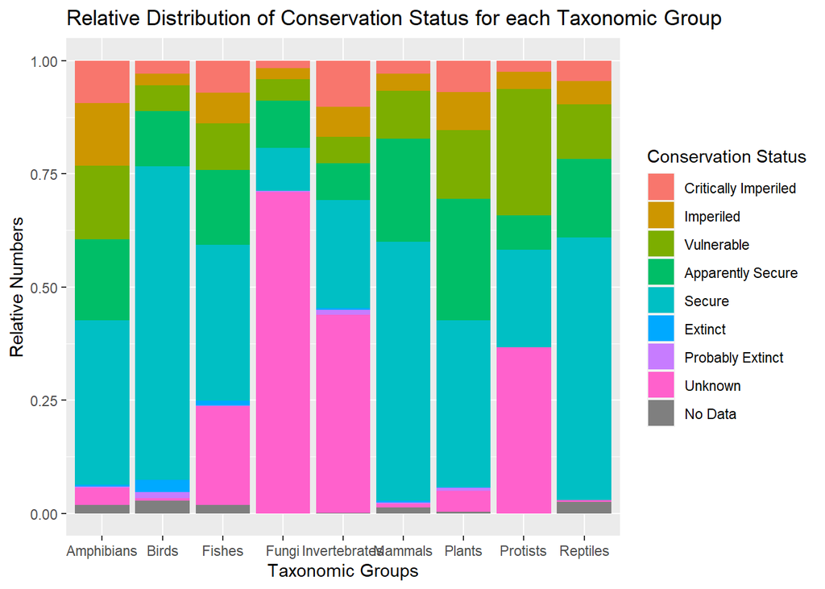

```r
ts <- data.frame (consdata$taxon, consdata$conservation_status)
colnames(ts) <- c("Taxonomic Groups", "Conservation Status")

library(ggplot2)
ggplot(ts, aes(`Taxonomic Groups`, fill=`Conservation Status`)) +
    geom_bar(position="fill", stat="count") +
    labs(title="Relative Distribution of Conservation Status for each Taxonomic Group", y = "Relative Numbers") +
    scale_fill_discrete(labels = c("Critically Imperiled", "Imperiled", "Vulnerable", "Apparently Secure", "Secure", "Extinct", "Probably Extinct", "Unknown", "No Data"))
```

3b) Based on this graph, what is something we might be concerned about in terms of analyzing the data on conservation status, particularly for fungi and invertebrates? (1 point)

**Answer:** There is a big proportion of Unknown (UNK) conservation status on Fungi and Invertebrates groups.

Read in the second data file: `spendingdata.csv`

```r
spend <- read.csv("spendingdata.csv")
```

This data set has a species ID that matches the species ID in the conservation data set (speciesid), year, and the spending on conservation of that species (expressed in 2015 dollars, i.e., accounting for inflation)

4a) Make a plot showing the distribution of spending in the year 2016 (3 points)

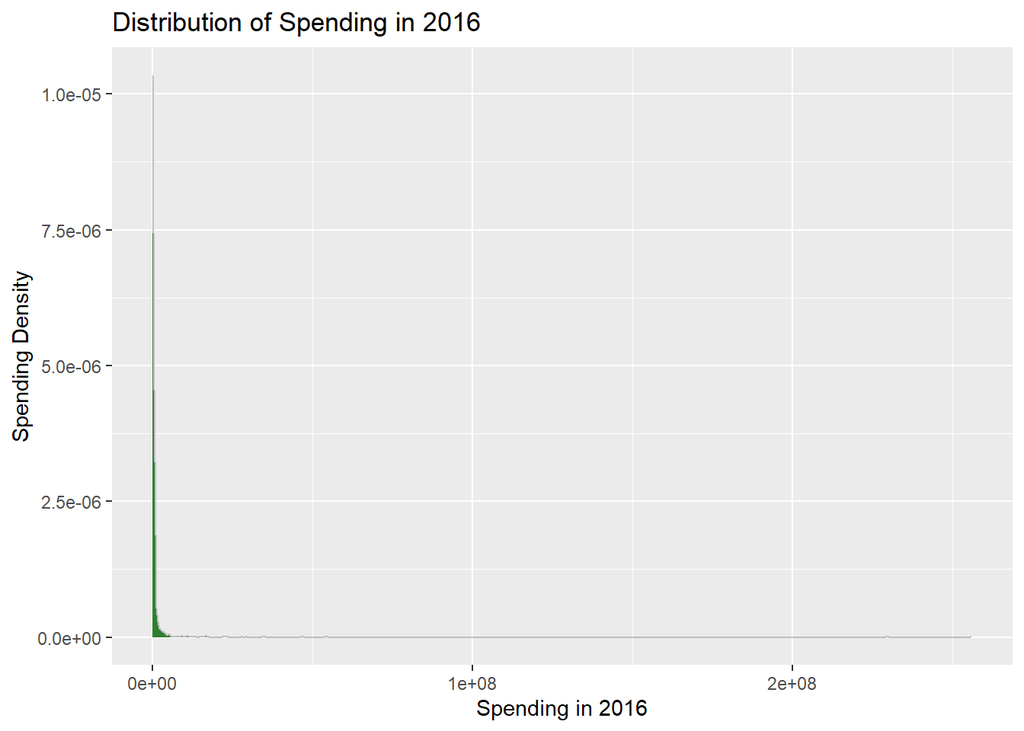

```r
sp2016 <- subset(spend, Year == "2016")

ggplot(sp2016, aes(x=spending)) +
  geom_density(fill="darkgreen", color="grey", alpha=0.8) +
  labs(title="Distribution of Spending in 2016", x="Spending in 2016", y="Spending Density")
```

4b) Notice the (very) long right tail on spending data - we spend a lot on a very small number of species. Show the IDs of the 3 species with the most spending in 2016. (2 points)

```r
head (sp2016[order(sp2016$spending, decreasing=TRUE),])
```

```
##      speciesid Year  spending
## 2095      1632 2016 255893066
## 4627      4486 2016 229175092
## 2220      1684 2016  54122671
## 2670      2033 2016  46811029
## 5577      5011 2016  46597547
## 908        712 2016  34656266
```

The 3 Species ID with most spending in 2016 are **#1632**, **#4486**, and **#1684**

5. Merge in the data from the conservation status data frame to the spending data frame, so that we have information on species names, taxonomic group, and conservation status with the spending data. (2 points); and use that to show the scientific names of the three species identified above.

```r
cosp <- merge(consdata, spend, by="speciesid")

top1 <- cosp[which(cosp$Year == "2016" & cosp$speciesid == "1632"),]
top2 <- cosp[which(cosp$Year == "2016" & cosp$speciesid == "4486"),]
top3 <- cosp[which(cosp$Year == "2016" & cosp$speciesid == "1684"),]

spc <- data.frame()
spc <- rbind.data.frame(top1, top2, top3)
spc
```

```
##      speciesid              speciesname  taxon conservation_status listed Year
## 2191      1632 Oncorhynchus tshawytscha Fishes                   5      1 2016
## 4744      4486      Oncorhynchus mykiss Fishes                   5      1 2016
## 2316      1684     Oncorhynchus kisutch Fishes                   5      1 2016
##       spending
## 2191 255893066
## 4744 229175092
## 2316  54122671
```

Look up these scientific names - what is the common name for these species?

**Answer:**

```r
spc <- subset(spc, select=c(1,2))
name <- c("Chinook salmon", "Rainbow trout", "Coho salmon")
spc <- cbind.data.frame(spc, name)
colnames(spc) <- c("Species ID", "Species Name", "Common Name")
spc
```

```
##      Species ID             Species Name    Common Name
## 2191       1632 Oncorhynchus tshawytscha Chinook salmon
## 4744       4486      Oncorhynchus mykiss  Rainbow trout
## 2316       1684     Oncorhynchus kisutch    Coho salmon
```

6. Finally, we will use a regression to look at the relationship between spending and species taxon.

Because the distribution of spending is very right-skewed, it would be a good idea to take the logarithm of spending before using it in a regression.

Remember that log(0)=infinity. That means we have to drop observations with zero spending before taking the logarithm.

1. Drop the rows where spending == 0 from the data frame and then make a new column with the logarithm (log()) of spending in each year. (2 points)

Optional: Look at the distribution of the logged spending variable and see how it looks different from the plot you made in question 4a

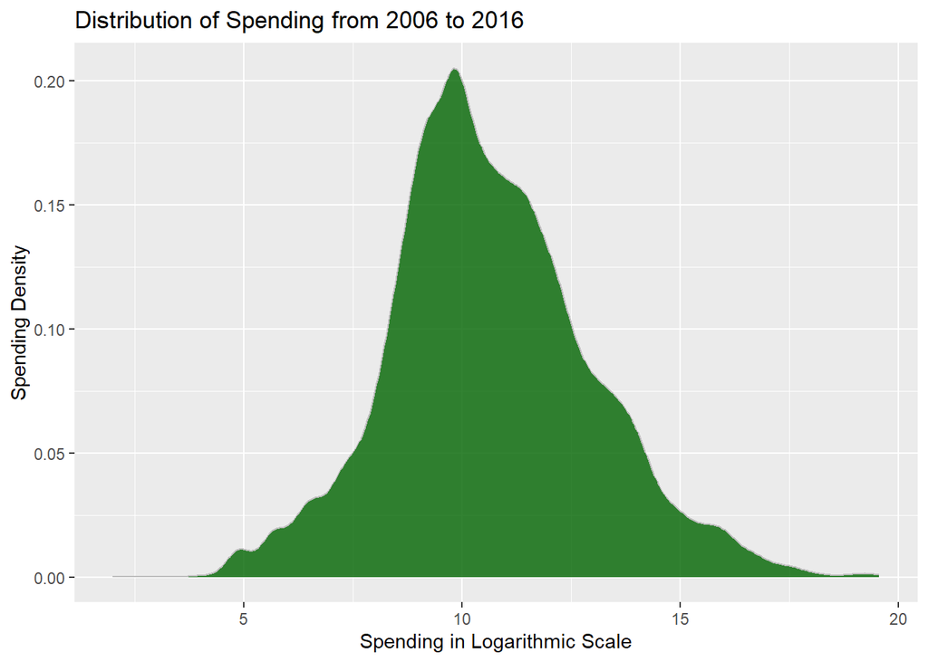

```r
cslog <- cosp[cosp$spending!="0",]
cslog <- transform(
  cslog, log_spending = log(cslog$spending))

ggplot(cslog, aes(x=log_spending)) +
  geom_density(fill="darkgreen", color="grey", alpha=0.8) +
  labs(title="Distribution of Spending from 2006 to 2016", x="Spending in Logarithmic Scale", y="Spending Density")
```

2. Run a regression of logged spending on taxonomic group and print the summary for the regression below (3 points)

```r
reg <- lm(log_spending~taxon, data=cslog)
summary.lm(reg)
```

```
##
## Call:
## lm(formula = log_spending ~ taxon, data = cslog)
##
## Residuals:
##     Min      1Q  Median      3Q     Max
## -8.7311 -1.1848  0.0171  1.3813  7.4867
##
## Coefficients:
##                    Estimate Std. Error t value Pr(>|t|)
## (Intercept)        11.64222    0.09488 122.700  < 2e-16 ***
## taxonBirds          0.87617    0.10555   8.301  < 2e-16 ***
## taxonFishes         0.43339    0.10266   4.222 2.43e-05 ***
## taxonFungi         -1.63702    0.32276  -5.072 3.97e-07 ***
## taxonInvertebrates -0.64918    0.09927  -6.540 6.28e-11 ***
## taxonMammals        1.03077    0.10690   9.643  < 2e-16 ***
## taxonPlants        -1.92320    0.09628 -19.975  < 2e-16 ***
## taxonReptiles       0.48029    0.12093   3.972 7.16e-05 ***
## ---
## Signif. codes:  0 '***' 0.001 '**' 0.01 '*' 0.05 '.' 0.1 ' ' 1
##
## Residual standard error: 1.999 on 26963 degrees of freedom
## Multiple R-squared:  0.2402, Adjusted R-squared:   0.24
## F-statistic:  1218 on 7 and 26963 DF,  p-value: < 2.2e-16
```

3. The way to interpret these coefficients are as the fractional difference in spending between the taxonomic group (e.g. Birds, Fishes, etc) and the “dropped” group, where by default the dropped group will be Amphibians. Positive numbers indicate that group has more spent on it than Amphibians and negative numbers indicate it has less spent on it.

Based on your results in b, do we see statistically significant differences in spending between different taxonomic groups? If so, which kinds of species tend to have more spent on them and which have less? (1 points)

**Answer:**

Taxonomic group that have the most spend is **Mammals**. It is seen its Estimate number of **1.03077** that is the largest positive number of Estimate Coefficient.

Taxonomic group that have the least spend is **Plants**. It is seen its Estimate number of **-1.92320** that is the largest negative number of Estimate Coefficient.

7. Push your R markdown file to your Github repository (2 points)